# Chapter 2: Statistics

# Key Ideas

Population, sample, random sample, with replacement, without replacement, bias, theoretical distribution, kurtosis, skew, Cullen and Frey graph, statistic, mean, median, minimum, maximum, quartiles, standard deviation, z-score, standard error, confidence interval, confidence level.

# Populations and Samples

A **population** is the entire universe of known observations. A **sample** is a subset of the population. For example, we can take a sample of all Iris flowers by querying for only those observations whose species is *setosa*

```r
#function to check if a package is installed
is_installed <- function(mypkg) is.element(mypkg, installed.packages()[,1])
#read in a population
df.iris.population <- as.data.frame(iris)
#take a sample
condition <- (df.iris.population$Species == 'setosa')
df.iris.sample.setosa <- df.iris.population[condition,]
df.iris.sample.setosa[1:5,]
```

```
  Sepal.Length Sepal.Width Petal.Length Petal.Width Species
1          5.1         3.5          1.4         0.2  setosa
2          4.9         3.0          1.4         0.2  setosa
3          4.7         3.2          1.3         0.2  setosa
4          4.6         3.1          1.5         0.2  setosa
5          5.0         3.6          1.4         0.2  setosa
```

The sample above was selected based on the condition that each member be in the *setosa* species. We can also create a **random sample** by selecting each observation from the population completely by chance.

We select **with replacement** when, after selecting an observation, when put the observation back into the population. We select **without replacement** when, after selecting an observation, we remove that observation from the population. When taking a random sample, selecting with replacement means that a particular observation may show up more than once in the resulting sample.

```r
#take a random sample
population_size = as.numeric(nrow(df.iris.population))
sample_size = 50
replacement = FALSE
df.iris.sample.random <- df.iris.population[sample(1:population_size, sample_size,replace=replacement),]
df.iris.sample.random[1:10,]
```

```
    Sepal.Length Sepal.Width Petal.Length Petal.Width    Species
115          5.8         2.8          5.1         2.4  virginica
67           5.6         3.0          4.5         1.5 versicolor
23           4.6         3.6          1.0         0.2     setosa
91           5.5         2.6          4.4         1.2 versicolor
54           5.5         2.3          4.0         1.3 versicolor
60           5.2         2.7          3.9         1.4 versicolor
78           6.7         3.0          5.0         1.7 versicolor
45           5.1         3.8          1.9         0.4     setosa
118          7.7         3.8          6.7         2.2  virginica
42           4.5         2.3          1.3         0.3     setosa
```

## Distributions

The distribution of the *setosa* Iris sample is different from the distribution of the random sample. We can see the difference by looking at histograms of the petal widths for both samples. Below is the histogram for the random sample.

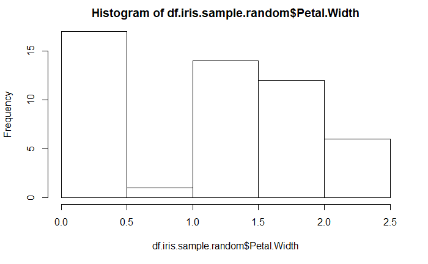

```r
#the histogram for the petal width of an unbiased sample
hist(df.iris.sample.random$Petal.Width)
```

And here is the histogram for the setosa sample.

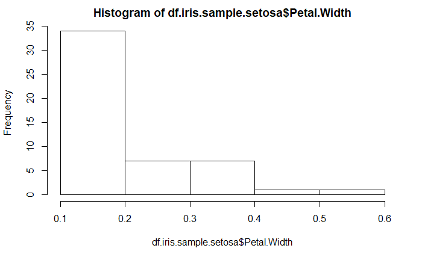

```r
#the histogram for the petal width of a biased sample
hist(df.iris.sample.setosa$Petal.Width)
```

The setosa sample is **biased.** An unusual number of observations have a relatively low petal width. This bias means that the setosa sample is no longer a good representation of the original population. The distribution for the random sample is a reasonable approximation of the original population. Below is the histogram for the original population for comparison.

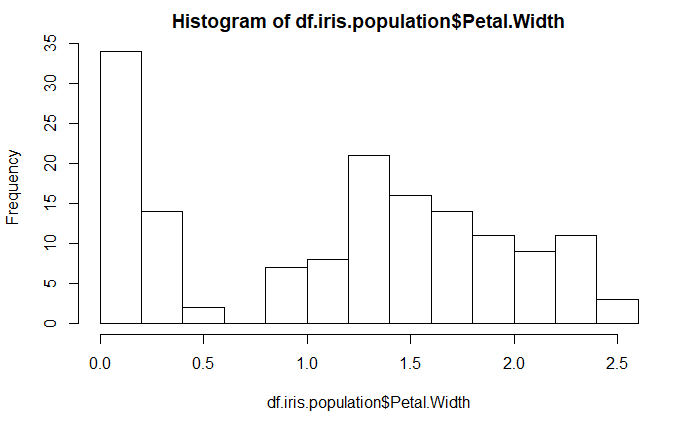

```r
#histogram of the petal width of the iris population
hist(df.iris.population$Petal.Width)
```

As things change, you can see the shape change

[interactive chart not shown]

Specific distributions can be categorized into **theoretical distributions** based on their general shape. The shape of a distribution is defined by both the *pointyness* of the curve (kurtosis) and the *lopsideness* (skew). The different shapes give clues about the properties of the population.

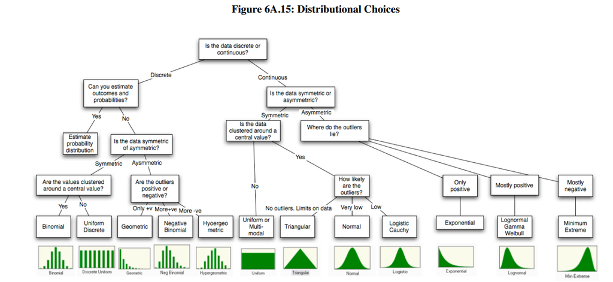

Source: pinterst

We can categorize a particular distribution into a theoretical distribution based a measure of the population’s kurtosis and skew. A **Cullen and Frey graph** tells us how to categorize a particular distribution based on a measurement of its kurtosis and skew.

```
summary statistics
------
min:  2   max:  4.4
median:  3
mean:  3.057333
estimated sd:  0.4358663
estimated skewness:  0.3189657
estimated kurtosis:  3.228249
```

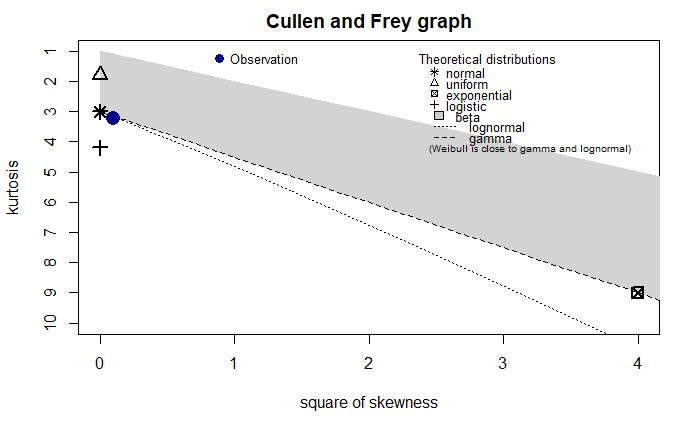

```r
#install and include the required package(s)
if(!is_installed("fitdistrplus")){install.packages("fitdistrplus")}
library(fitdistrplus)
#determine the distribution of the petal width feature
#Skewness (existance of a tail) and Kurtosis (pointyness) determines the type of distribution
descdist(df.iris.population$Sepal.Width, discrete = FALSE)
```

## Statistical Measures

A **statistic** is a number that characterizes a set of obervations. For example, below is a set of observations of the air quality on various days.

```r
df.air_quality <- as.data.frame(airquality)
df.air_quality[1:5,]
```

```
  Ozone Solar.R Wind Temp Month Day
1    41     190  7.4   67     5   1
2    36     118  8.0   72     5   2
3    12     149 12.6   74     5   3
4    18     313 11.5   62     5   4
5    NA      NA 14.3   56     5   5
```

The temperature is distributed as shown in the following histogram.

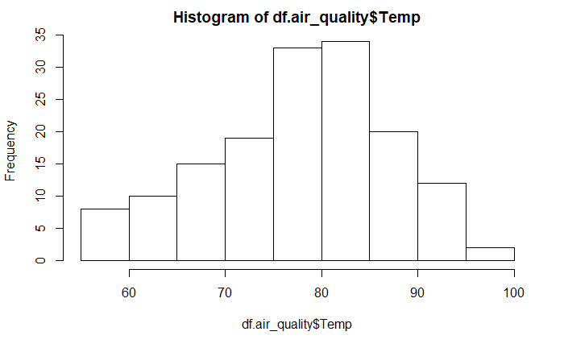

```r
hist(df.air_quality$Temp)
```

We can characterize the temperature using statistics like mean, median, minimum and maximum and quartile. **Quartiles** divide an ordered data set into 4 equal parts, so that each part contains 1/4 of the data set.

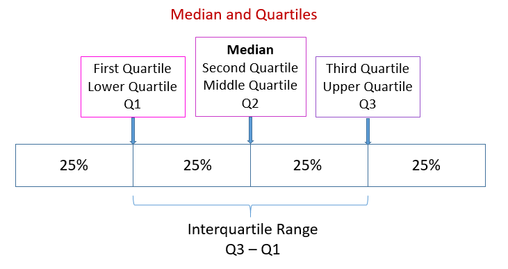

Source: OnlineMathLearning.com

```r
print(paste("The average (mean) temperature is", mean(df.air_quality$Temp)))
```

```
[1] "The average (mean) temperature is 77.8823529411765"
```

```r
print(paste("The middle (median) temperature is", median(df.air_quality$Temp)))
```

```
[1] "The middle (median) temperature is 79"
```

```r
print(paste("The lowest observed temperature was", min(df.air_quality$Temp)))
```

```
[1] "The lowest observed temperature was 56"
```

```r
print(paste("The highest observed temperature was", max(df.air_quality$Temp)))
```

```
[1] "The highest observed temperature was 97"
```

```r
print(paste("3/4 of all termperatures were above", quantile(df.air_quality$Temp)[2])) #1st quartile
```

```
[1] "3/4 of all termperatures were above 72"
```

```r
print(paste("1/4 of all termperatures were above", quantile(df.air_quality$Temp)[4])) #3rd quartile
```

```
[1] "1/4 of all termperatures were above 85"
```

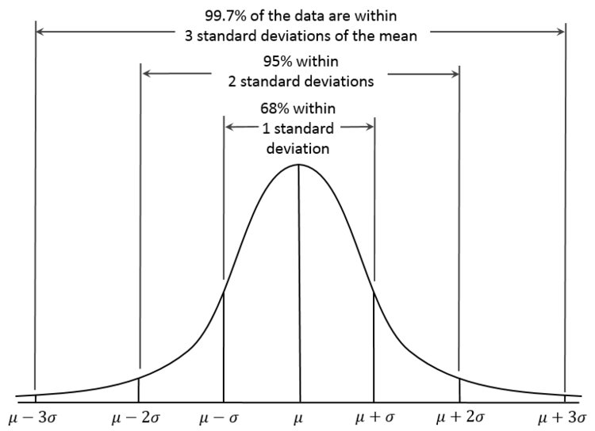

Source: BusinessInsider.com

The standard deviation can be used to rescale different features to a standard measure known as the **z-score.** A z-score is the number of standard deviations from mean. From the air quality observations, wind speed and air temperature are normally on different scales and hard to compare.

But if we rescale both according to z-scores, comparison becomes easier. Below, we see the air quality observations scaled to z-scores. In the first observation, both wind speed and temperature are lower than normal. Wind speed is 0.73 standard deviations below the mean, while temperature is 1.15 standard deviations below the mean.

```r
#map values from different distributions onto a universal scale (standard deviation)
temp.scaled <- scale(df.air_quality$Temp, center = TRUE, scale = TRUE)
wind.scaled <- scale(df.air_quality$Wind, center = TRUE, scale = TRUE)
df.air_quality.scaled <- data.frame(wind.scaled, temp.scaled)
df.air_quality.scaled[1:10,]
```

```
   wind.scaled temp.scaled
1   -0.7259482  -1.1497140
2   -0.5556388  -0.6214670
3    0.7500660  -0.4101682
4    0.4378323  -1.6779609
5    1.2326091  -2.3118573
6    1.4029185  -1.2553634
7   -0.3853295  -1.3610128
8    1.0906847  -1.9949091
9    2.8789327  -1.7836103
10  -0.3853295  -0.9384152
```

## Confidence Intervals

The value of a statistic will change depending on the sample used. The value that we get for a mean temperature, for example, depends on the observed temperatures in a particular sample.

```r
population_size = as.numeric(nrow(df.air_quality))
sample_size = 10
replacement = TRUE
#create three different random samples of air temperature
sample1 <- df.air_quality[sample(1:population_size, sample_size,replace=replacement),4]
sample2 <- df.air_quality[sample(1:population_size, sample_size,replace=replacement),4]
sample3 <- df.air_quality[sample(1:population_size, sample_size,replace=replacement),4]

#take the mean temperature from each sample
print(paste("The mean temperature of Sample 1 is", mean(sample1)))
```

```
[1] "The mean temperature of Sample 1 is 82.4"
```

```r
print(paste("The mean temperature of Sample 2 is", mean(sample2)))
```

```
[1] "The mean temperature of Sample 2 is 83"
```

```r
print(paste("The mean temperature of Sample 3 is", mean(sample3)))
```

```
[1] "The mean temperature of Sample 3 is 81.5"
```

The **standard error** of a statistic is the standard deviation of that statistic over all samples. From the example above, the standard error of the mean temperature is the standard deviation of the means calculated from samples 1-3. We can, however, estimate the standard error using just a single sample.

```r
stderr <- function(x, na.rm=FALSE) {
  if (na.rm) x <- na.omit(x)
  sqrt(var(x)/length(x))
}
standard_error <- stderr(sample1)
print(paste("The estimated standard error of the mean temperature is", standard_error))
```

```
[1] "The estimated standard error of the mean temperature is 1.84511366707974"
```

The standard error can be used to calculate a range of expected values (a **confidence interval**) for a statistic. For example, assuming a normal distribution, we can assume that 68% of the time, a calculated statistic will fall within the standard error of the statistic observed.

```r
statistic <- mean(sample1)
lower_bound <- statistic - standard_error
upper_bound <- statistic + standard_error
print(paste("We are 68% confident that the temperature mean is between", lower_bound, "and", upper_bound))
```

```
[1] "We are 68% confident that the temperature mean is between 80.5548863329203 and 84.2451136670797"
```

We can calculate a confidence interval based on a desired **confidence level**.

```r
confidence_interval <- function(sample, confidence) {
  # Standard deviation of sample
  vec_sd <- sd(sample)
  # Sample size
  n <- length(sample)
  # Mean of sample
  vec_mean <- mean(sample)
  # Error according to t distribution
  error <- qt((confidence + 1)/2, df = n - 1) * vec_sd / sqrt(n)
  # Confidence interval as a vector
  result <- c("lower" = vec_mean - error, "upper" = vec_mean + error)
  return(result)
}
```

50% confidence interval for the mean temperature

```r
confidence_interval(sample1, .50)
```

```
  lower   upper
81.1034 83.6966
```

80% confidence interval for the mean temperature

```r
confidence_interval(sample1, .80)
```

```
   lower    upper
79.84815 84.95185
```

99% confidence interval for the mean temperature

```r
confidence_interval(sample1, .99)
```

```
   lower    upper
76.40368 88.39632
```